Домашнее задание №4.

Работу выполнила: Шишкина Валерия, 3821Б1ФИ3

```python
import numpy as np
import matplotlib.pyplot as plt
import pandas as pd
%matplotlib inline
```

```python
data = pd.read_csv('C:/Users/ЛЕРА/Desktop/data.csv')
pd.set_option('display.max_columns', None)
```

```python
data.isnull().sum()
```

```
id                     0
gender                 0
age                    0
hypertension           0
heart_disease          0
ever_married           0
work_type              0
Residence_type         0
avg_glucose_level      0
bmi                  201
smoking_status         0
stroke                 0
dtype: int64
```

```python
data['bmi'] = data['bmi'].fillna(data['bmi'].mean())
data.isnull().sum()
```

```
id                   0
gender               0
age                  0
hypertension         0
heart_disease        0
ever_married         0
work_type            0
Residence_type       0
avg_glucose_level    0
bmi                  0
smoking_status       0
stroke               0
dtype: int64
```

```python
category_columns = [
    'gender', 'ever_married', 'work_type', 'Residence_type',
    'smoking_status']

for column in category_columns:
    data[column] = data[column].astype('category')
```

```python
data = pd.get_dummies(data, columns=['ever_married', 'work_type', 'Residence_type', 'smoking_status'], drop_first=True)

print(data.head())
```

```
      id  gender   age  hypertension  heart_disease  avg_glucose_level  \
0   9046    Male  67.0             0              1             228.69
1  51676  Female  61.0             0              0             202.21
2  31112    Male  80.0             0              1             105.92
3  60182  Female  49.0             0              0             171.23
4   1665  Female  79.0             1              0             174.12

         bmi  stroke  ever_married_Yes  work_type_Never_worked  \
0  36.600000       1              True                   False
1  28.893237       1              True                   False
2  32.500000       1              True                   False
3  34.400000       1              True                   False
4  24.000000       1              True                   False

   work_type_Private  work_type_Self-employed  work_type_children  \
```

[output cut: 19 more lines]

```python
columns_to_convert = [
    'gender',
    'ever_married_Yes',
    'work_type_Never_worked',
    'work_type_Private',
    'work_type_Self-employed',
    'work_type_children',
    'Residence_type_Urban',
    'smoking_status_formerly smoked',
    'smoking_status_never smoked',
    'smoking_status_smokes'
]

data[columns_to_convert] = data[columns_to_convert].replace({True: 1, False: 0})
```

```python
data
```

|  | id | gender | age | hypertension | heart_disease | avg_glucose_level | bmi | stroke | ever_married_Yes | work_type_Never_worked | work_type_Private | work_type_Self-employed | work_type_children | Residence_type_Urban | smoking_status_formerly smoked | smoking_status_never smoked | smoking_status_smokes |
| --- | --- | --- | --- | --- | --- | --- | --- | --- | --- | --- | --- | --- | --- | --- | --- | --- | --- |
| 0 | 9046 | Male | 67.0 | 0 | 1 | 228.69 | 36.600000 | 1 | 1 | 0 | 1 | 0 | 0 | 1 | 1 | 0 | 0 |
| 1 | 51676 | Female | 61.0 | 0 | 0 | 202.21 | 28.893237 | 1 | 1 | 0 | 0 | 1 | 0 | 0 | 0 | 1 | 0 |
| 2 | 31112 | Male | 80.0 | 0 | 1 | 105.92 | 32.500000 | 1 | 1 | 0 | 1 | 0 | 0 | 0 | 0 | 1 | 0 |
| 3 | 60182 | Female | 49.0 | 0 | 0 | 171.23 | 34.400000 | 1 | 1 | 0 | 1 | 0 | 0 | 1 | 0 | 0 | 1 |
| 4 | 1665 | Female | 79.0 | 1 | 0 | 174.12 | 24.000000 | 1 | 1 | 0 | 0 | 1 | 0 | 0 | 0 | 1 | 0 |
| ... | ... | ... | ... | ... | ... | ... | ... | ... | ... | ... | ... | ... | ... | ... | ... | ... | ... |
| 5105 | 18234 | Female | 80.0 | 1 | 0 | 83.75 | 28.893237 | 0 | 1 | 0 | 1 | 0 | 0 | 1 | 0 | 1 | 0 |
| 5106 | 44873 | Female | 81.0 | 0 | 0 | 125.20 | 40.000000 | 0 | 1 | 0 | 0 | 1 | 0 | 1 | 0 | 1 | 0 |
| 5107 | 19723 | Female | 35.0 | 0 | 0 | 82.99 | 30.600000 | 0 | 1 | 0 | 0 | 1 | 0 | 0 | 0 | 1 | 0 |
| 5108 | 37544 | Male | 51.0 | 0 | 0 | 166.29 | 25.600000 | 0 | 1 | 0 | 1 | 0 | 0 | 0 | 1 | 0 | 0 |
| 5109 | 44679 | Female | 44.0 | 0 | 0 | 85.28 | 26.200000 | 0 | 1 | 0 | 0 | 0 | 0 | 1 | 0 | 0 | 0 |

5110 rows × 17 columns

```python
data['gender'] = data['gender'].map({'Male': 0, 'Female': 1})
```

```python
data
```

|  | id | gender | age | hypertension | heart_disease | avg_glucose_level | bmi | stroke | ever_married_Yes | work_type_Never_worked | work_type_Private | work_type_Self-employed | work_type_children | Residence_type_Urban | smoking_status_formerly smoked | smoking_status_never smoked | smoking_status_smokes |
| --- | --- | --- | --- | --- | --- | --- | --- | --- | --- | --- | --- | --- | --- | --- | --- | --- | --- |
| 0 | 9046 | 0 | 67.0 | 0 | 1 | 228.69 | 36.600000 | 1 | 1 | 0 | 1 | 0 | 0 | 1 | 1 | 0 | 0 |
| 1 | 51676 | 1 | 61.0 | 0 | 0 | 202.21 | 28.893237 | 1 | 1 | 0 | 0 | 1 | 0 | 0 | 0 | 1 | 0 |
| 2 | 31112 | 0 | 80.0 | 0 | 1 | 105.92 | 32.500000 | 1 | 1 | 0 | 1 | 0 | 0 | 0 | 0 | 1 | 0 |
| 3 | 60182 | 1 | 49.0 | 0 | 0 | 171.23 | 34.400000 | 1 | 1 | 0 | 1 | 0 | 0 | 1 | 0 | 0 | 1 |
| 4 | 1665 | 1 | 79.0 | 1 | 0 | 174.12 | 24.000000 | 1 | 1 | 0 | 0 | 1 | 0 | 0 | 0 | 1 | 0 |
| ... | ... | ... | ... | ... | ... | ... | ... | ... | ... | ... | ... | ... | ... | ... | ... | ... | ... |
| 5105 | 18234 | 1 | 80.0 | 1 | 0 | 83.75 | 28.893237 | 0 | 1 | 0 | 1 | 0 | 0 | 1 | 0 | 1 | 0 |
| 5106 | 44873 | 1 | 81.0 | 0 | 0 | 125.20 | 40.000000 | 0 | 1 | 0 | 0 | 1 | 0 | 1 | 0 | 1 | 0 |
| 5107 | 19723 | 1 | 35.0 | 0 | 0 | 82.99 | 30.600000 | 0 | 1 | 0 | 0 | 1 | 0 | 0 | 0 | 1 | 0 |
| 5108 | 37544 | 0 | 51.0 | 0 | 0 | 166.29 | 25.600000 | 0 | 1 | 0 | 1 | 0 | 0 | 0 | 1 | 0 | 0 |
| 5109 | 44679 | 1 | 44.0 | 0 | 0 | 85.28 | 26.200000 | 0 | 1 | 0 | 0 | 0 | 0 | 1 | 0 | 0 | 0 |

5110 rows × 17 columns

```python
X = data.drop(['stroke', 'id'], axis=1)
y = data['stroke']
```

```python
from sklearn.cluster import KMeans
from sklearn.preprocessing import StandardScaler
from imblearn.over_sampling import SMOTE
smote = SMOTE(random_state=42)
X_resampled, y_resampled = smote.fit_resample(X, y)
```

```python
scaler = StandardScaler()
X_scaled = scaler.fit_transform(X_resampled)
```

```python
from sklearn.impute import SimpleImputer

imputer = SimpleImputer(strategy='mean')
X_imputed = imputer.fit_transform(X)

scaler = StandardScaler()
X_scaled_imputed = scaler.fit_transform(X_imputed)
```

```python
kmeans = KMeans(n_clusters=98, random_state=42)
data['KMeans_Cluster'] = kmeans.fit_predict(X_scaled_imputed)
silhouette_kmeans = silhouette_score(X_scaled_imputed, data['KMeans_Cluster'])
print(f"Silhouette Score for KMeans: {silhouette_kmeans}")
```

```
Silhouette Score for KMeans: 0.3286946024229516
```

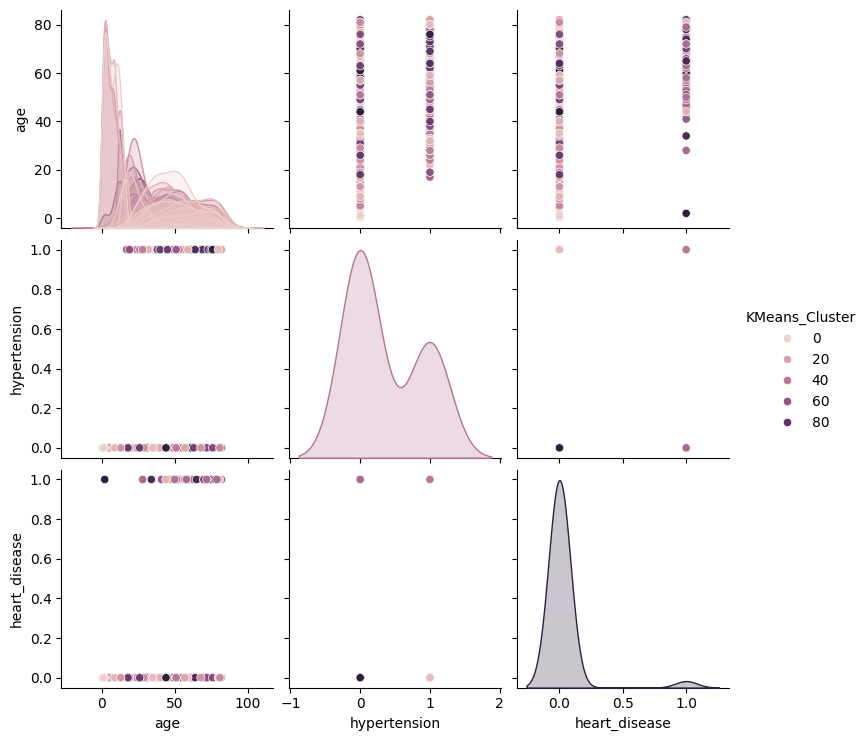

```python
import seaborn as sns
import matplotlib.pyplot as plt
sns.pairplot(data, vars=['age', 'hypertension', 'heart_disease'], hue='KMeans_Cluster')
plt.show()
```

```python
for k in set(data['KMeans_Cluster']):
    a = y[data['KMeans_Cluster']==k]
    print(f"Кластер: {k}, %1 = {round(sum(a)/len(a), 2)}")
```

```
Кластер: 0, %1 = 0.04
Кластер: 1, %1 = 0.0
Кластер: 2, %1 = 0.03
Кластер: 3, %1 = 0.06
Кластер: 4, %1 = 0.02
Кластер: 5, %1 = 0.0
Кластер: 6, %1 = 0.0
Кластер: 7, %1 = 0.13
Кластер: 8, %1 = 0.11
Кластер: 9, %1 = 0.08
Кластер: 10, %1 = 0.17
Кластер: 11, %1 = 0.22
Кластер: 12, %1 = 0.0
Кластер: 13, %1 = 0.05
Кластер: 14, %1 = 0.07
Кластер: 15, %1 = 0.03
Кластер: 16, %1 = 0.0
Кластер: 17, %1 = 0.05
Кластер: 18, %1 = 0.12
Кластер: 19, %1 = 0.02
Кластер: 20, %1 = 0.05
Кластер: 21, %1 = 0.09
Кластер: 22, %1 = 0.0
Кластер: 23, %1 = 0.06
Кластер: 24, %1 = 0.12
Кластер: 25, %1 = 0.01
Кластер: 26, %1 = 0.01
Кластер: 27, %1 = 0.04
Кластер: 28, %1 = 0.02
Кластер: 29, %1 = 0.03
Кластер: 30, %1 = 0.0
Кластер: 31, %1 = 0.09
Кластер: 32, %1 = 0.02
Кластер: 33, %1 = 0.03
Кластер: 34, %1 = 0.01
Кластер: 35, %1 = 0.16
Кластер: 36, %1 = 0.02
Кластер: 37, %1 = 0.06
Кластер: 38, %1 = 0.03
Кластер: 39, %1 = 0.11
```

[output cut: 43 more lines]

```
Кластер: 83, %1 = 0.0
Кластер: 84, %1 = 0.17
Кластер: 85, %1 = 0.23
Кластер: 86, %1 = 0.16
Кластер: 87, %1 = 0.1
Кластер: 88, %1 = 0.06
Кластер: 89, %1 = 0.08
Кластер: 90, %1 = 0.04
Кластер: 91, %1 = 0.05
Кластер: 92, %1 = 0.19
Кластер: 93, %1 = 0.02
Кластер: 94, %1 = 0.2
Кластер: 95, %1 = 0.0
Кластер: 96, %1 = 0.0
Кластер: 97, %1 = 0.1
```

```python
from sklearn.cluster import DBSCAN

dbscan = DBSCAN(eps=1.9, min_samples=10)
data['DBSCAN_Cluster'] = dbscan.fit_predict((X_scaled_imputed))
silhouette_dbscan = silhouette_score((X_scaled_imputed), data['DBSCAN_Cluster'])
print(f"Silhouette Score for DBSCAN: {silhouette_dbscan}")
```

```
Silhouette Score for DBSCAN: 0.26179446701111553
```

```python
for k in set(data['DBSCAN_Cluster']):
    a = y[data['DBSCAN_Cluster']==k]
    print(f"Кластер: {k}, %1 = {round(sum(a)/len(a), 2)}")
```

```
Кластер: 0, %1 = 0.06
Кластер: 1, %1 = 0.05
Кластер: 2, %1 = 0.22
Кластер: 3, %1 = 0.12
Кластер: 4, %1 = 0.02
Кластер: 5, %1 = 0.04
Кластер: 6, %1 = 0.04
Кластер: 7, %1 = 0.09
Кластер: 8, %1 = 0.12
Кластер: 9, %1 = 0.04
Кластер: 10, %1 = 0.07
Кластер: 11, %1 = 0.09
Кластер: 12, %1 = 0.02
Кластер: 13, %1 = 0.04
Кластер: 14, %1 = 0.03
Кластер: 15, %1 = 0.08
Кластер: 16, %1 = 0.08
Кластер: 17, %1 = 0.1
Кластер: 18, %1 = 0.09
Кластер: 19, %1 = 0.07
Кластер: 20, %1 = 0.03
Кластер: 21, %1 = 0.09
Кластер: 22, %1 = 0.09
Кластер: 23, %1 = 0.03
Кластер: 24, %1 = 0.01
Кластер: 25, %1 = 0.03
Кластер: 26, %1 = 0.06
Кластер: 27, %1 = 0.03
Кластер: 28, %1 = 0.09
Кластер: 29, %1 = 0.09
Кластер: 30, %1 = 0.03
Кластер: 31, %1 = 0.04
Кластер: 32, %1 = 0.05
Кластер: 33, %1 = 0.11
Кластер: 34, %1 = 0.1
Кластер: 35, %1 = 0.07
Кластер: 36, %1 = 0.07
Кластер: 37, %1 = 0.06
Кластер: 38, %1 = 0.01
Кластер: 39, %1 = 0.07
```

[output cut: 34 more lines]

```
Кластер: 74, %1 = 0.0
Кластер: 75, %1 = 0.0
Кластер: 76, %1 = 0.0
Кластер: 77, %1 = 0.0
Кластер: 78, %1 = 0.0
Кластер: 79, %1 = 0.0
Кластер: 80, %1 = 0.0
Кластер: 81, %1 = 0.0
Кластер: 82, %1 = 0.0
Кластер: 83, %1 = 0.0
Кластер: 84, %1 = 0.0
Кластер: 85, %1 = 0.2
Кластер: 86, %1 = 0.3
Кластер: 87, %1 = 0.0
Кластер: -1, %1 = 0.11
```

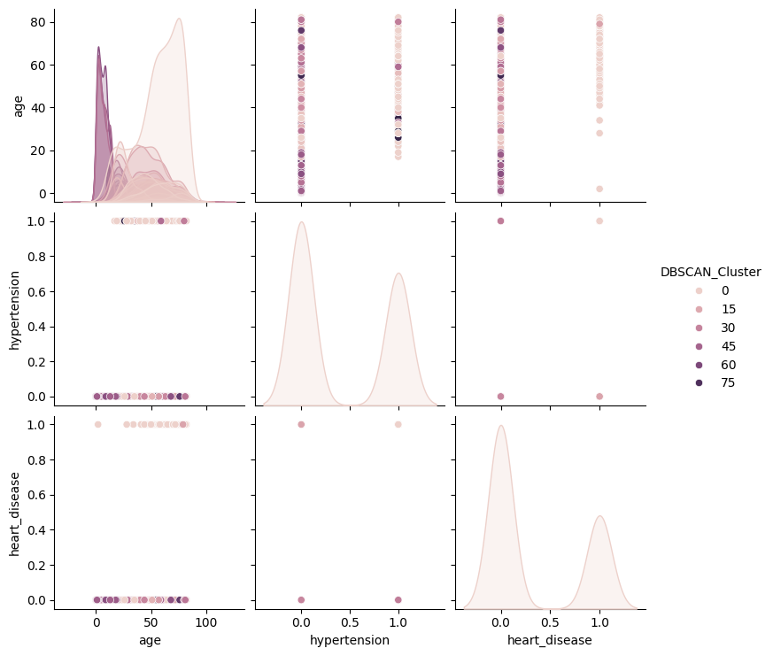

```python
sns.pairplot(data, vars=['age', 'hypertension', 'heart_disease'], hue='DBSCAN_Cluster')
plt.show()
```

```python
from sklearn.cluster import AgglomerativeClustering

agg_clustering = AgglomerativeClustering(n_clusters=100)
data['Agglomerative_Cluster'] = agg_clustering.fit_predict(X_scaled_imputed)
silhouette_agg = silhouette_score(X_scaled_imputed, data['Agglomerative_Cluster'])
print(f"Silhouette Score for Agglomerative Clustering: {silhouette_agg}")
```

```
Silhouette Score for Agglomerative Clustering: 0.3297891192112478
```

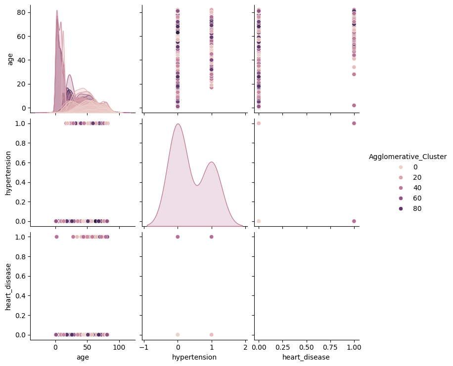

```python
sns.pairplot(data, vars=['age', 'hypertension', 'heart_disease'], hue='Agglomerative_Cluster')
plt.show()
```

```python
for k in set(data['Agglomerative_Cluster']):
    a = y[data['Agglomerative_Cluster']==k]
    print(f"Кластер: {k}, %1 = {round(sum(a)/len(a), 2)}")
```

```
Кластер: 0, %1 = 0.08
Кластер: 1, %1 = 0.18
Кластер: 2, %1 = 0.07
Кластер: 3, %1 = 0.04
Кластер: 4, %1 = 0.03
Кластер: 5, %1 = 0.02
Кластер: 6, %1 = 0.19
Кластер: 7, %1 = 0.07
Кластер: 8, %1 = 0.11
Кластер: 9, %1 = 0.14
Кластер: 10, %1 = 0.03
Кластер: 11, %1 = 0.07
Кластер: 12, %1 = 0.0
Кластер: 13, %1 = 0.0
Кластер: 14, %1 = 0.14
Кластер: 15, %1 = 0.1
Кластер: 16, %1 = 0.15
Кластер: 17, %1 = 0.03
Кластер: 18, %1 = 0.02
Кластер: 19, %1 = 0.15
Кластер: 20, %1 = 0.11
Кластер: 21, %1 = 0.09
Кластер: 22, %1 = 0.0
Кластер: 23, %1 = 0.0
Кластер: 24, %1 = 0.02
Кластер: 25, %1 = 0.04
Кластер: 26, %1 = 0.02
Кластер: 27, %1 = 0.0
Кластер: 28, %1 = 0.04
Кластер: 29, %1 = 0.33
Кластер: 30, %1 = 0.0
Кластер: 31, %1 = 0.06
Кластер: 32, %1 = 0.03
Кластер: 33, %1 = 0.01
Кластер: 34, %1 = 0.0
Кластер: 35, %1 = 0.0
Кластер: 36, %1 = 0.14
Кластер: 37, %1 = 0.27
Кластер: 38, %1 = 0.02
Кластер: 39, %1 = 0.08
```

[output cut: 45 more lines]

```
Кластер: 85, %1 = 0.19
Кластер: 86, %1 = 0.4
Кластер: 87, %1 = 0.04
Кластер: 88, %1 = 0.08
Кластер: 89, %1 = 0.0
Кластер: 90, %1 = 0.0
Кластер: 91, %1 = 0.0
Кластер: 92, %1 = 0.0
Кластер: 93, %1 = 0.0
Кластер: 94, %1 = 0.0
Кластер: 95, %1 = 0.0
Кластер: 96, %1 = 0.0
Кластер: 97, %1 = 0.02
Кластер: 98, %1 = 0.09
Кластер: 99, %1 = 0.01
```

Полученные результаты

```python
print(f"Silhouette Score for KMeans: {silhouette_kmeans}")
print(f"Silhouette Score for DBSCAN: {silhouette_dbscan}")
print(f"Silhouette Score for Agglomerative Clustering: {silhouette_agg}")
best_score = max(silhouette_kmeans, silhouette_dbscan, silhouette_agg)

if best_score == silhouette_kmeans:
    best_algorithm = "KMeans"
elif best_score == silhouette_dbscan:
    best_algorithm = "DBSCAN"
else:
    best_algorithm = "Agglomerative Clustering"
print(f"The best algorithm based on Silhouette Score is: {best_algorithm} with a score of {best_score}")
```

```
Silhouette Score for KMeans: 0.3286946024229516
Silhouette Score for DBSCAN: 0.26179446701111553
Silhouette Score for Agglomerative Clustering: 0.3297891192112478
The best algorithm based on Silhouette Score is: Agglomerative Clustering with a score of 0.3297891192112478
```

Выводы: В ходе данной работы были рассмотрены и применены три алгоритма кластеризации: KMeans, DBSCAN и Agglomerative Clustering. Данные были распределены по кластерам с использованием каждого из алгоритмов. Для оценки качества кластеризации использовалась метрика Silhouette Score.

Silhouette score (силуэтный коэффициент) — это метрика, используемая для оценки качества кластеризации. Она измеряет, насколько объекты внутри кластера похожи друг на друга по сравнению с объектами в других кластерах. Силуэтный коэффициент варьируется от -1 до 1. Значение близкое к 1 указывает на хорошую кластеризацию, где объекты внутри кластера очень похожи друг на друга и сильно отличаются от объектов в других кластерах. Значение близкое к 0 указывает на перекрывающиеся кластеры, где объекты могут быть одинаково близки к объектам в других кластерах. Значение близкое к -1 указывает на плохую кластеризацию, где объекты внутри кластера могут быть более похожи на объекты в других кластерах, чем на объекты внутри своего кластера.

Был проведен анализ распределения целевой переменной y внутри каждого кластера, полученного с помощью алгоритмов. Кластеры с высоким процентом целевой переменной могут быть интересны для дальнейшего анализа, так как они содержат больше объектов с целевым значением 1.

Видим, что у всех трех методов положительный коэффициент, однако значения находятся близко к нулю, в идеальной ситуации оно должно быть близко к 1. Можно сказать, что кластеризация среднего качества. Кластеры не очень хорошо разделены и могут перекрываться. Agglomerative Clustering и KMeans показывают наилучшие результаты, но общее качество кластеризации среднее. DBSCAN показывает результаты хуже, что может говорить о сложности разделения данных этим методом.